# Herbivory_experiment_0824

Jiao

24 August 2018

# **1. Aim**

Explore data via plotting plant traits (biomass, number of trichome, absolute leaf area eaten by herbivores) and herbivore/caterpillar performance (relative growth rate/RGR) combining with spatial data.

# **2. Data preparation**

```r
# load library
library(tidyverse)
# read data

## caterpillar weight in 4 days
caterpillar <- read.csv("caterpillar.wt_HT.csv", header = TRUE)
View(caterpillar)
## calculate RGR
cater.RGR <- caterpillar %>%
  mutate(RGR = (log(d5/d1)) / (5-1))
View(cater.RGR)

## number of trichome
trichome <- read.csv("no.trichomes_HT.csv", header = TRUE)
View(trichome)

## plant above- and belowground biomass
plant.biomass <- read.csv("plant.biomass_HT.csv", header = TRUE)
plant.biomass <- merge(plant.biomass, trichome, by=c("genotype", "replicate", "treatment"))

## leaf area
area.C <- read.csv("area_control.csv", header = TRUE)
View(area.C)
area.H <- read.csv("area_herbivory.csv", header = TRUE)
View(area.H)

# read spatial data
BU <- read.csv("mother_BU.csv", header = TRUE)
View(BU)
```

# **3. Correlations and changes of variables**

# **3.1 Correlations of variables**

Correlations among relative growth rate (RGR) of caterpillars and number of trichomes, absolute leaf area damaged by caterpillars.

```r
# select values of trichomes from herbivore treatment
trichome.H <- filter(trichome, treatment == "H")
View(trichome.H)

# create new working dataframe combining three variables: relative growth rate (RGR) of caterpillars, number of trichomes, absolute leaf area damaged by caterpillars.
herbivory <- merge(cater.RGR, trichome.H, by = c("genotype", "replicate"))
herbivory <- merge(herbivory, area.H, by = c("genotype", "replicate"))
herbivory <- cbind(cater.RGR, trichome.H[4], area.H[,-(1:3)])
View(herbivory)
herbivory$genotype <- as.factor(herbivory$genotype)

# correlations of RGR, number of trichome, parameters related to leaf area
cor.herbivory <- select(herbivory, RGR, trichome, area.undamaged, area.total, area.damaged, perc.damaged)
round(cor(cor.herbivory), 2)
```

```
##                  RGR trichome area.undamaged area.total area.damaged
## RGR             1.00    -0.08          -0.06      -0.05         0.11
## trichome       -0.08     1.00          -0.82      -0.82        -0.30
## area.undamaged -0.06    -0.82           1.00       1.00         0.30
## area.total     -0.05    -0.82           1.00       1.00         0.38
## area.damaged    0.11    -0.30           0.30       0.38         1.00
## perc.damaged   -0.03     0.55          -0.51      -0.48         0.18
##                perc.damaged
## RGR                   -0.03
## trichome               0.55
## area.undamaged        -0.51
## area.total            -0.48
## area.damaged           0.18
## perc.damaged           1.00
```

```r
cor.test(herbivory$trichome, herbivory$RGR)
```

```
##
##  Pearson's product-moment correlation
##
## data:  herbivory$trichome and herbivory$RGR
## t = -0.75406, df = 88, p-value = 0.4528
## alternative hypothesis: true correlation is not equal to 0
## 95 percent confidence interval:
##  -0.2825278  0.1291088
## sample estimates:
##         cor
## -0.08012467
```

```r
cor.test(herbivory$area.damaged, herbivory$RGR)
```

```
##
##  Pearson's product-moment correlation
##
## data:  herbivory$area.damaged and herbivory$RGR
## t = 0.99649, df = 88, p-value = 0.3217
## alternative hypothesis: true correlation is not equal to 0
## 95 percent confidence interval:
##  -0.1037280  0.3060288
## sample estimates:
##       cor
## 0.1056322
```

```r
cor.test(herbivory$trichome, herbivory$area.damaged)
```

```
##
##  Pearson's product-moment correlation
##
## data:  herbivory$trichome and herbivory$area.damaged
## t = -2.9787, df = 88, p-value = 0.003741
## alternative hypothesis: true correlation is not equal to 0
## 95 percent confidence interval:
##  -0.4796650 -0.1019334
## sample estimates:
##       cor
## -0.302636
```

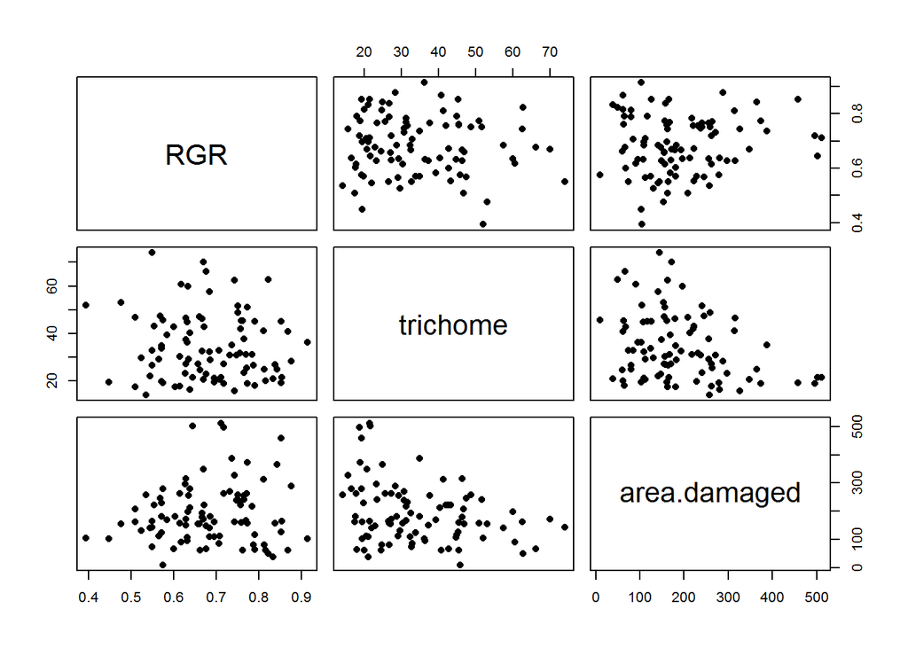

```r
# plot in one single image
newdata <- herbivory[, c(1,8:9,12)]
plot(newdata[,-1], pch=16)
```

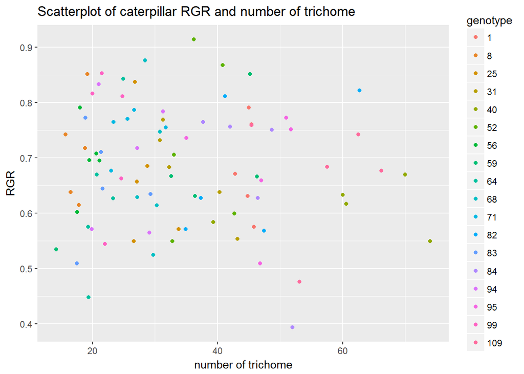

```r
# make scatterplots colored by "genotype"
library(ggplot2)
ggplot(herbivory, aes(trichome, RGR, color=genotype)) +
  geom_point() +
  labs(title = "Scatterplot of caterpillar RGR and number of trichome", x = "number of trichome", y = "RGR")
```

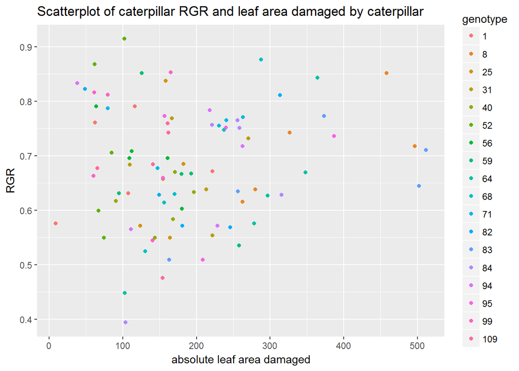

```r
ggplot(herbivory, aes(area.damaged, RGR, color=genotype)) +
  geom_point() +
  labs(title = "Scatterplot of caterpillar RGR and leaf area damaged by caterpillar", x = "absolute leaf area damaged", y = "RGR")
```

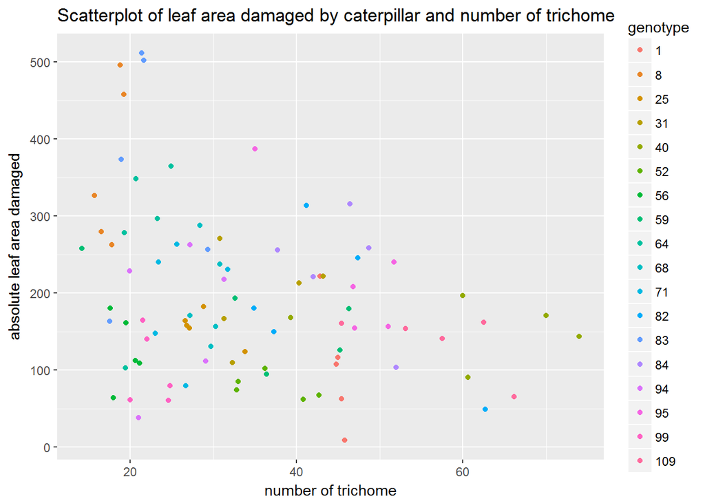

```r
ggplot(herbivory, aes(trichome, area.damaged, color=genotype)) +
  geom_point() +
  labs(title = "Scatterplot of leaf area damaged by caterpillar and number of trichome", x = "number of trichome", y = "absolute leaf area damaged")
```

Results: There is small positive correlations between RGR of caterpillars with absolute leaf area damaged by caterpillars (p = 0.11) and small negative correlation with number of trichome (p = -0.08), while a significant negative correlation between absolute leaf area damaged by caterpillars and number of trichome (p = -0.30).

# **3.2 Changes of variables with urbanisation**

Changes of relative growth rate (RGR) of caterpillars, number of trichomes, absolute leaf area damaged by caterpillars, per genotype ordered by urbanisation at different spatial scales.

```r
# How RGR, leaf area damaged by herbivores, number of trichome per genotype with urbanisation. Make scatterplots.

# Select available dataframes: "herbivory" ,"trichome".
# Summarize the mean and sd.
library(plyr)
mRGR.area <- ddply(herbivory, "genotype", summarise,
                   mRGR = mean(RGR),
                   sd.RGR = sd(RGR),
                   marea = mean(area.damaged),
                   sd.area = sd(area.damaged)
                   )


mtric <- ddply(trichome, c("genotype", "treatment"), summarise,
                   mtric = mean(trichome),
                   sd.tric =sd(trichome)
                   )


# add spatial data
mRGR.area.BU <- merge(mRGR.area, BU, by="genotype")

mtric.BU <- merge(mtric, BU, by="genotype")
mtric.BU$genotype <- factor(mtric.BU$genotype)
```

# **3.2.1 At 50m scale**

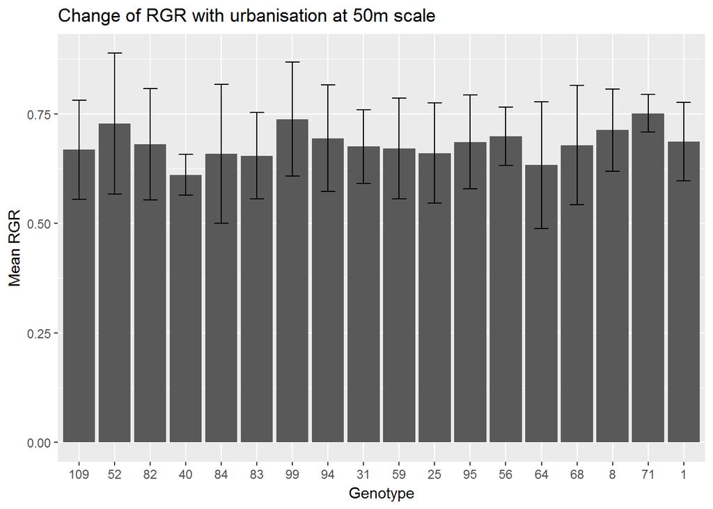

```r
# order genotypes by urbanisation
mRGR.area.BU <- mRGR.area.BU %>% arrange(d50) %>%
  mutate(genotype = factor(genotype, unique(genotype)))

mtric.BU <- mtric.BU %>% arrange(d50) %>%
  mutate(genotype = factor(genotype, unique(genotype)))

# make error bar plots
p.RGR50 <- ggplot(mRGR.area.BU, aes(x=genotype, y=mRGR)) +
  geom_bar(stat = "identity",
           position = position_dodge()) +
  geom_errorbar(aes(ymin=mRGR-sd.RGR, ymax=mRGR+sd.RGR), width=.4,
                position = position_dodge(.9)) +
  labs(title="Change of RGR with urbanisation at 50m scale", x="Genotype", y="Mean RGR")
p.RGR50
```

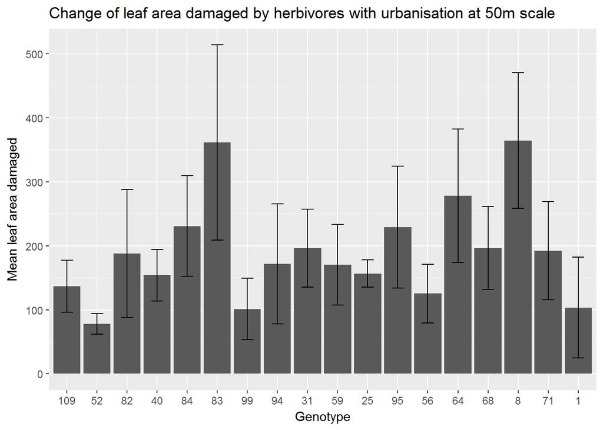

```r
p.area50 <- ggplot(mRGR.area.BU, aes(x=genotype, y=marea)) +
  geom_bar(stat = "identity",
           position = position_dodge()) +
  geom_errorbar(aes(ymin=marea-sd.area, ymax=marea+sd.area), width=.4,
                position = position_dodge(.9)) +
  labs(title="Change of leaf area damaged by herbivores with urbanisation at 50m scale", x="Genotype", y="Mean leaf area damaged")
p.area50
```

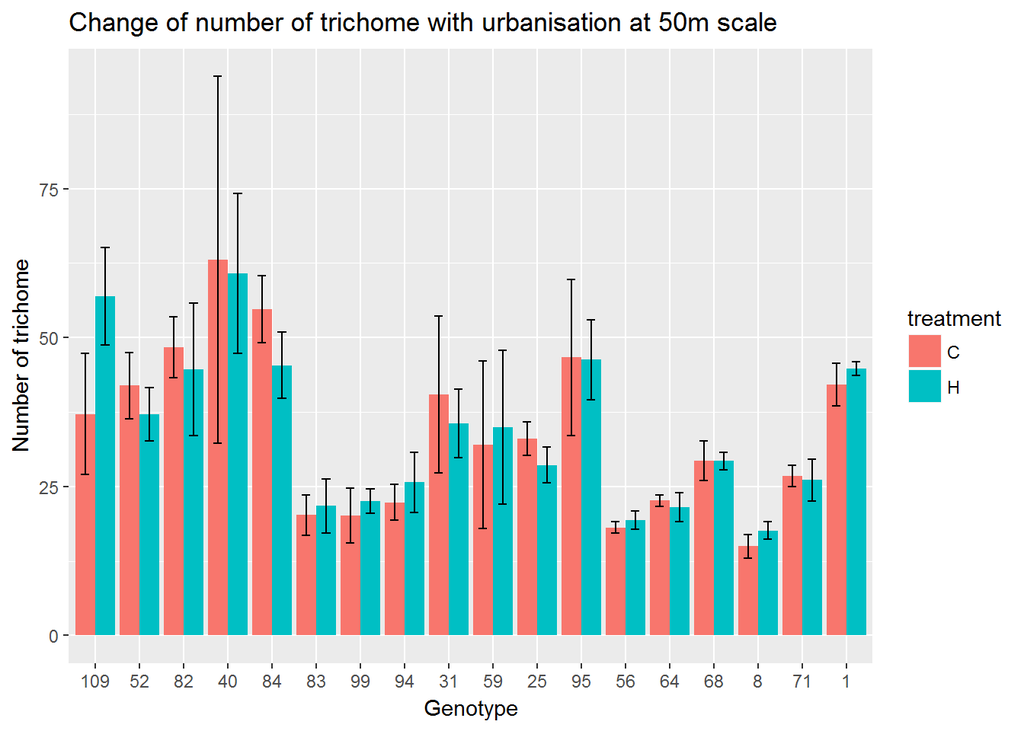

```r
p.tric50 <- ggplot(mtric.BU, aes(x=genotype, y=mtric, fill=treatment)) +
  geom_bar(stat = "identity",
           position = position_dodge()) +
  geom_errorbar(aes(ymin=mtric-sd.tric, ymax=mtric+sd.tric), width=.4,
                position = position_dodge(.9)) +
  labs(title="Change of number of trichome with urbanisation at 50m scale", x="Genotype", y="Number of trichome")
p.tric50
```

# **3.2.2 At 100m scale**

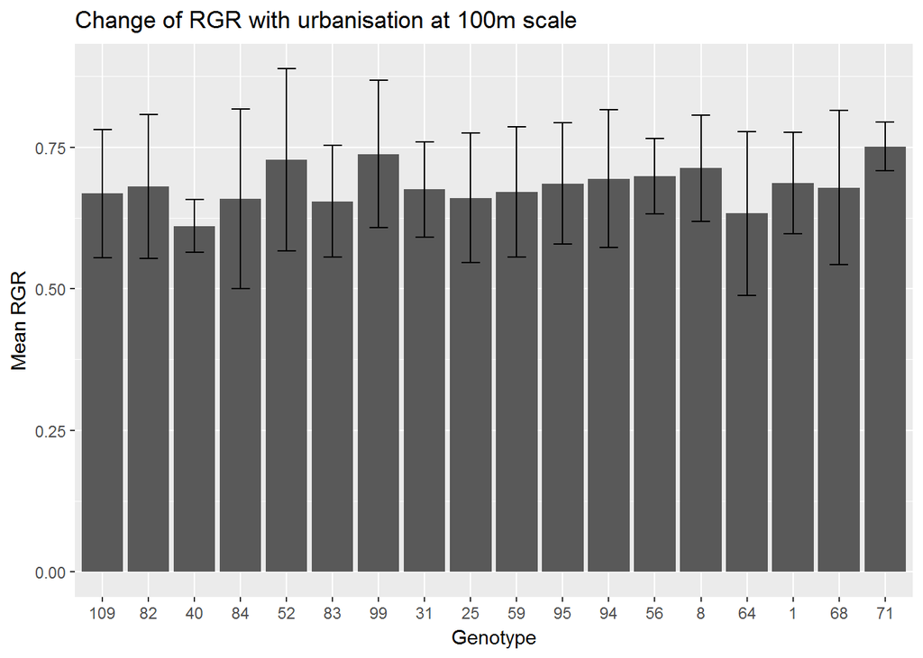

```r
# order genotypes by urbanisation
mRGR.area.BU <- mRGR.area.BU %>% arrange(d100) %>%
  mutate(genotype = factor(genotype, unique(genotype)))

mtric.BU <- mtric.BU %>% arrange(d100) %>%
  mutate(genotype = factor(genotype, unique(genotype)))

# make error bar plots
p.RGR100 <- ggplot(mRGR.area.BU, aes(x=genotype, y=mRGR)) +
  geom_bar(stat = "identity",
           position = position_dodge()) +
  geom_errorbar(aes(ymin=mRGR-sd.RGR, ymax=mRGR+sd.RGR), width=.4,
                position = position_dodge(.9)) +
  labs(title="Change of RGR with urbanisation at 100m scale", x="Genotype", y="Mean RGR")
p.RGR100
```

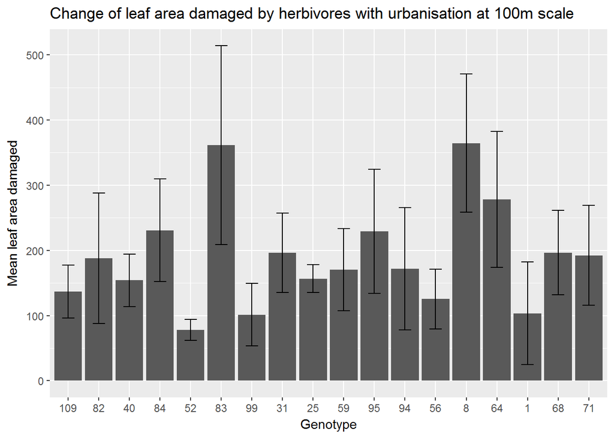

```r
p.area100 <- ggplot(mRGR.area.BU, aes(x=genotype, y=marea)) +
  geom_bar(stat = "identity",
           position = position_dodge()) +
  geom_errorbar(aes(ymin=marea-sd.area, ymax=marea+sd.area), width=.4,
                position = position_dodge(.9)) +
  labs(title="Change of leaf area damaged by herbivores with urbanisation at 100m scale", x="Genotype", y="Mean leaf area damaged")
p.area100
```

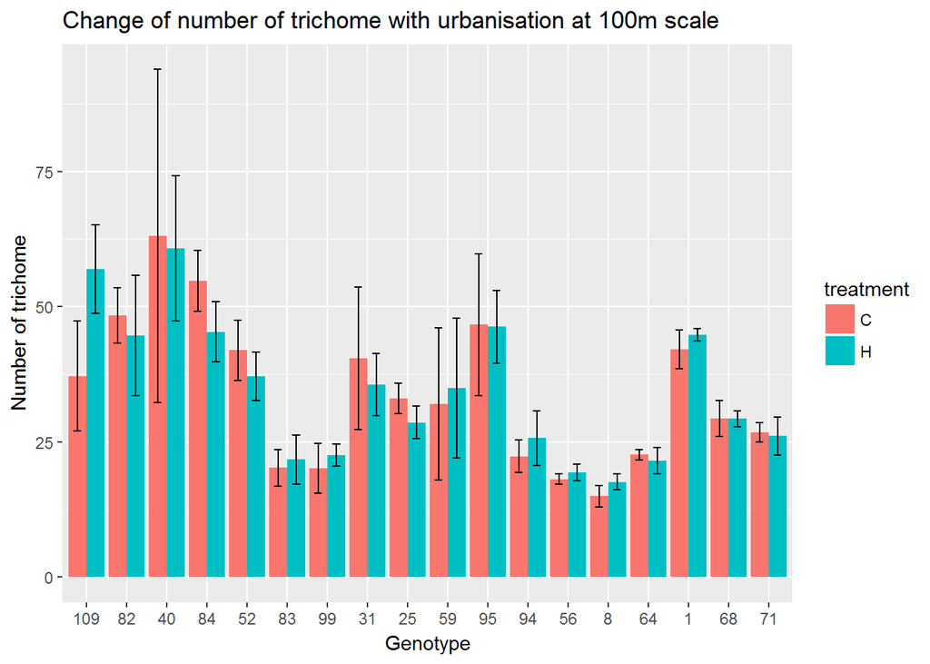

```r
p.tric100 <- ggplot(mtric.BU, aes(x=genotype, y=mtric, fill=treatment)) +
  geom_bar(stat = "identity",
           position = position_dodge()) +
  geom_errorbar(aes(ymin=mtric-sd.tric, ymax=mtric+sd.tric), width=.4,
                position = position_dodge(.9)) +
  labs(title="Change of number of trichome with urbanisation at 100m scale", x="Genotype", y="Number of trichome")
p.tric100
```

# **3.2.3 At 200m scale**

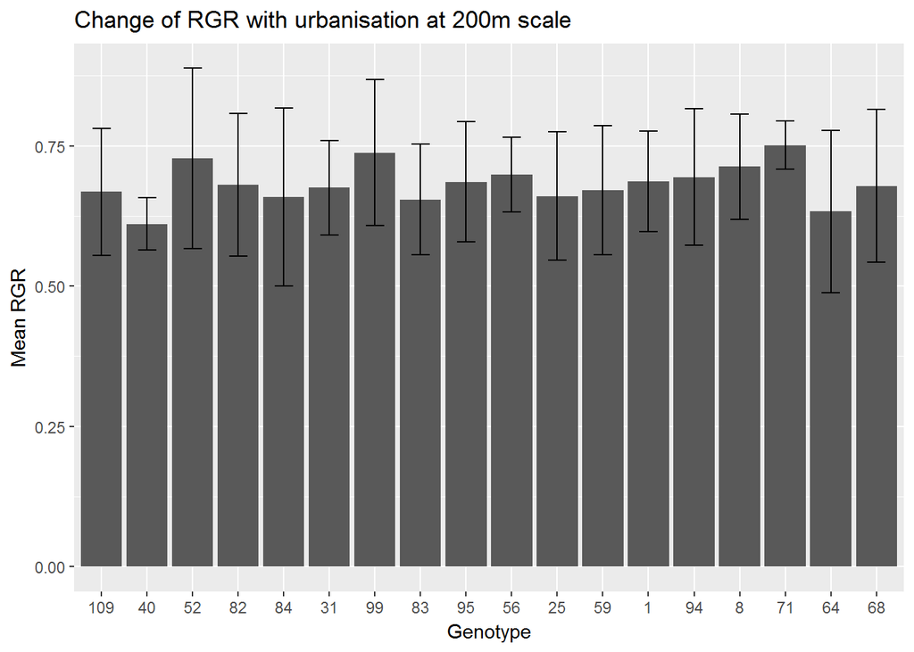

```r
# order genotypes by urbanisation
mRGR.area.BU <- mRGR.area.BU %>% arrange(d200) %>%
  mutate(genotype = factor(genotype, unique(genotype)))

mtric.BU <- mtric.BU %>% arrange(d200) %>%
  mutate(genotype = factor(genotype, unique(genotype)))

# make error bar plots
p.RGR200 <- ggplot(mRGR.area.BU, aes(x=genotype, y=mRGR)) +
  geom_bar(stat = "identity",
           position = position_dodge()) +
  geom_errorbar(aes(ymin=mRGR-sd.RGR, ymax=mRGR+sd.RGR), width=.4,
                position = position_dodge(.9)) +
  labs(title="Change of RGR with urbanisation at 200m scale", x="Genotype", y="Mean RGR")
p.RGR200
```

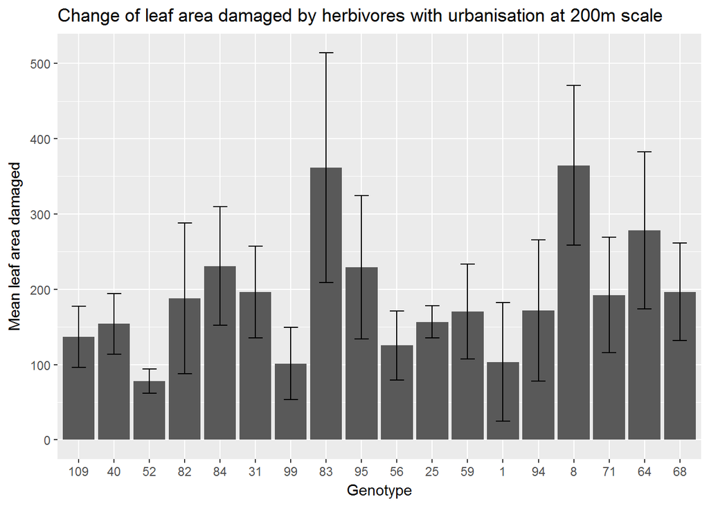

```r
p.area200 <- ggplot(mRGR.area.BU, aes(x=genotype, y=marea)) +
  geom_bar(stat = "identity",
           position = position_dodge()) +
  geom_errorbar(aes(ymin=marea-sd.area, ymax=marea+sd.area), width=.4,
                position = position_dodge(.9)) +
  labs(title="Change of leaf area damaged by herbivores with urbanisation at 200m scale", x="Genotype", y="Mean leaf area damaged")
p.area200
```

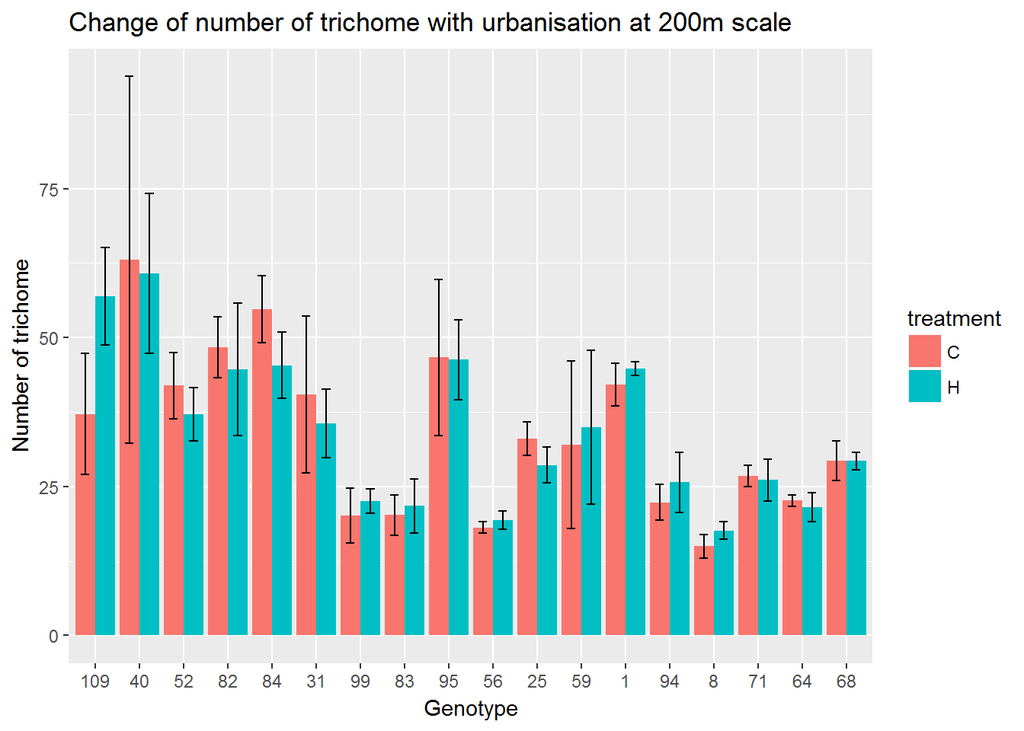

```r
p.tric200 <- ggplot(mtric.BU, aes(x=genotype, y=mtric, fill=treatment)) +
  geom_bar(stat = "identity",
           position = position_dodge()) +
  geom_errorbar(aes(ymin=mtric-sd.tric, ymax=mtric+sd.tric), width=.4,
                position = position_dodge(.9)) +
  labs(title="Change of number of trichome with urbanisation at 200m scale", x="Genotype", y="Number of trichome")
p.tric200
```

# **3.2.4 At 400m scale**

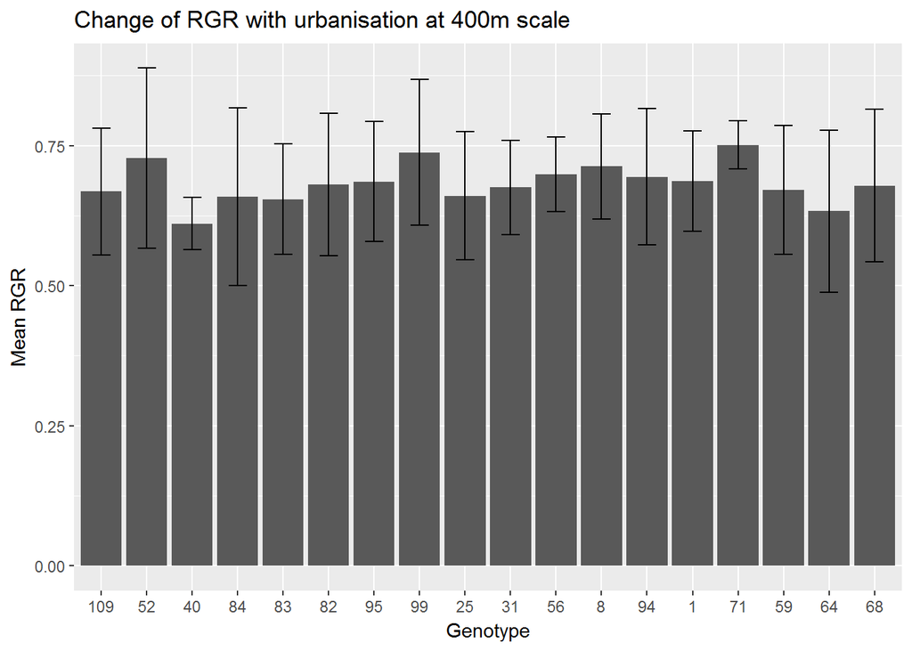

```r
# order genotypes by urbanisation
mRGR.area.BU <- mRGR.area.BU %>% arrange(d400) %>%
  mutate(genotype = factor(genotype, unique(genotype)))

mtric.BU <- mtric.BU %>% arrange(d400) %>%
  mutate(genotype = factor(genotype, unique(genotype)))

# make error bar plots
p.RGR400 <- ggplot(mRGR.area.BU, aes(x=genotype, y=mRGR)) +
  geom_bar(stat = "identity",
           position = position_dodge()) +
  geom_errorbar(aes(ymin=mRGR-sd.RGR, ymax=mRGR+sd.RGR), width=.4,
                position = position_dodge(.9)) +
  labs(title="Change of RGR with urbanisation at 400m scale", x="Genotype", y="Mean RGR")
p.RGR400
```

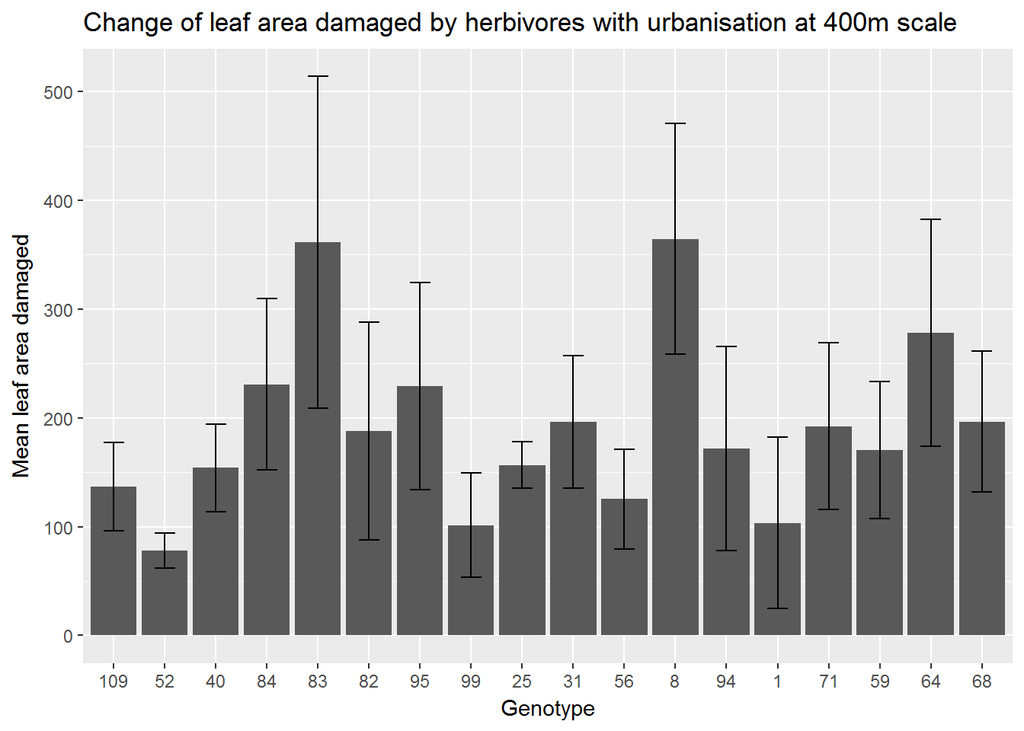

```r
p.area400 <- ggplot(mRGR.area.BU, aes(x=genotype, y=marea)) +
  geom_bar(stat = "identity",
           position = position_dodge()) +
  geom_errorbar(aes(ymin=marea-sd.area, ymax=marea+sd.area), width=.4,
                position = position_dodge(.9)) +
  labs(title="Change of leaf area damaged by herbivores with urbanisation at 400m scale", x="Genotype", y="Mean leaf area damaged")
p.area400
```

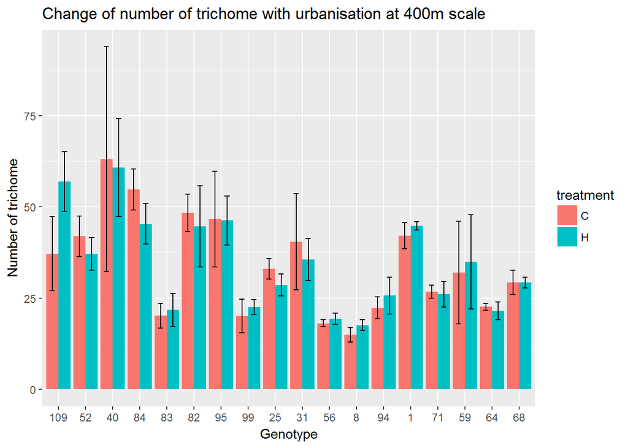

```r
p.tric400 <- ggplot(mtric.BU, aes(x=genotype, y=mtric, fill=treatment)) +
  geom_bar(stat = "identity",
           position = position_dodge()) +
  geom_errorbar(aes(ymin=mtric-sd.tric, ymax=mtric+sd.tric), width=.4,
                position = position_dodge(.9)) +
  labs(title="Change of number of trichome with urbanisation at 400m scale", x="Genotype", y="Number of trichome")
p.tric400
```

# **3.2.5 At 800m scale**

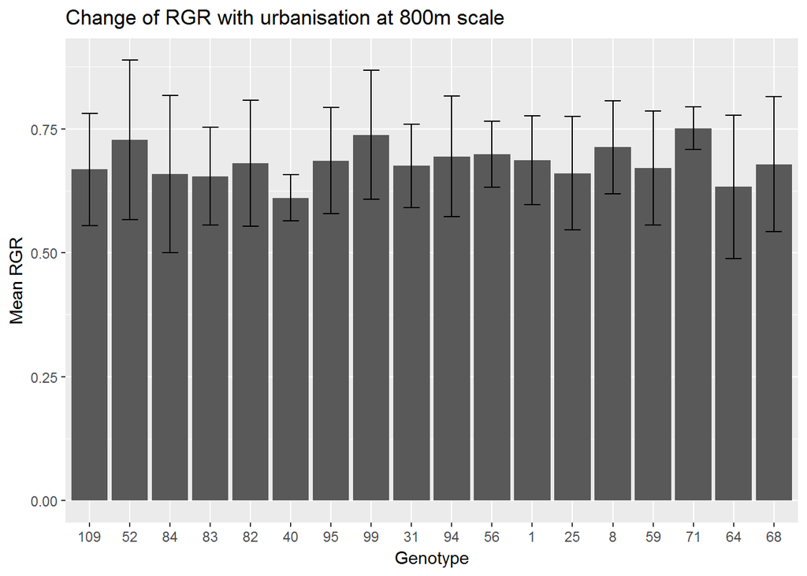

```r
# order genotypes by urbanisation
mRGR.area.BU <- mRGR.area.BU %>% arrange(d800) %>%
  mutate(genotype = factor(genotype, unique(genotype)))

mtric.BU <- mtric.BU %>% arrange(d800) %>%
  mutate(genotype = factor(genotype, unique(genotype)))

# make error bar plots
p.RGR800 <- ggplot(mRGR.area.BU, aes(x=genotype, y=mRGR)) +
  geom_bar(stat = "identity",
           position = position_dodge()) +
  geom_errorbar(aes(ymin=mRGR-sd.RGR, ymax=mRGR+sd.RGR), width=.4,
                position = position_dodge(.9)) +
  labs(title="Change of RGR with urbanisation at 800m scale", x="Genotype", y="Mean RGR")
p.RGR800
```

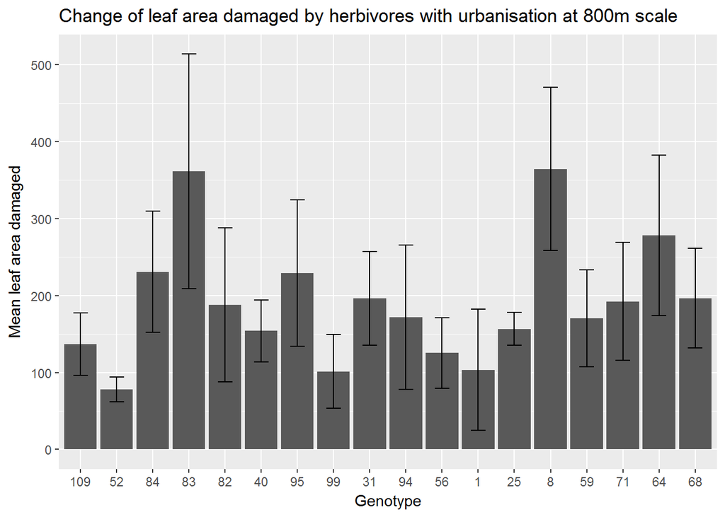

```r
p.area800 <- ggplot(mRGR.area.BU, aes(x=genotype, y=marea)) +
  geom_bar(stat = "identity",
           position = position_dodge()) +
  geom_errorbar(aes(ymin=marea-sd.area, ymax=marea+sd.area), width=.4,
                position = position_dodge(.9)) +
  labs(title="Change of leaf area damaged by herbivores with urbanisation at 800m scale", x="Genotype", y="Mean leaf area damaged")
p.area800
```

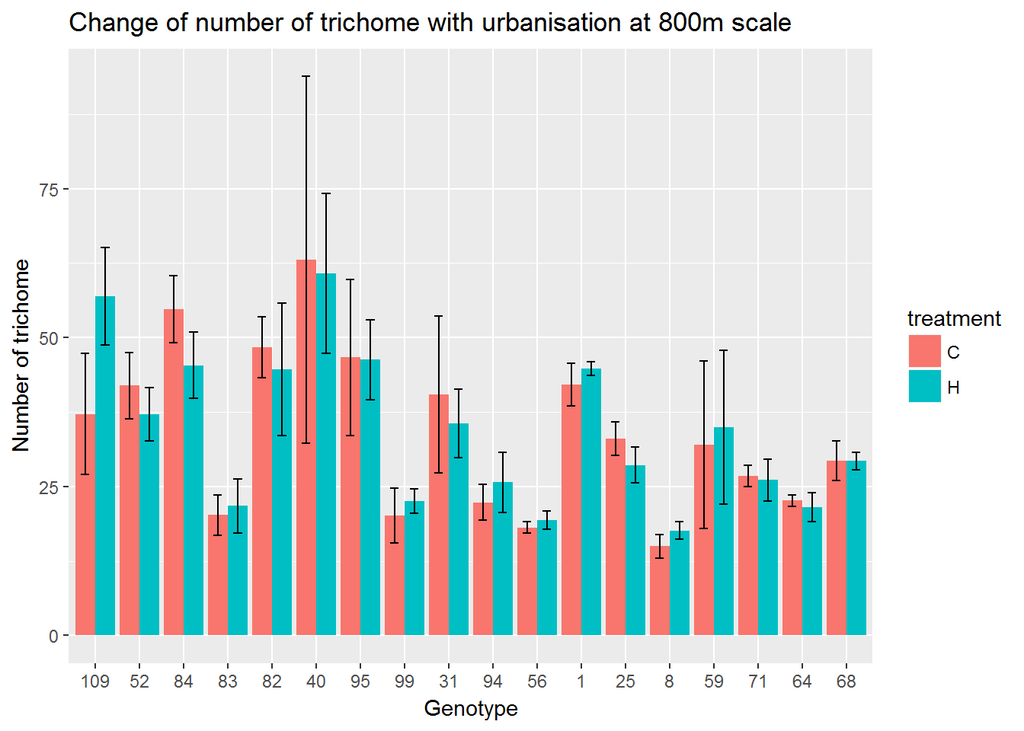

```r
p.tric800 <- ggplot(mtric.BU, aes(x=genotype, y=mtric, fill=treatment)) +
  geom_bar(stat = "identity",
           position = position_dodge()) +
  geom_errorbar(aes(ymin=mtric-sd.tric, ymax=mtric+sd.tric), width=.4,
                position = position_dodge(.9)) +
  labs(title="Change of number of trichome with urbanisation at 800m scale", x="Genotype", y="Number of trichome")
p.tric800
```

# **3.2.6 At 1600m scale**

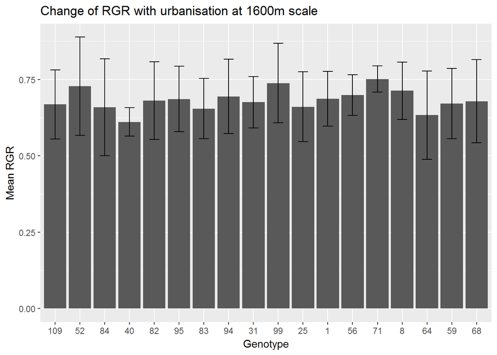

```r
# order genotypes by urbanisation
mRGR.area.BU <- mRGR.area.BU %>% arrange(d1600) %>%
  mutate(genotype = factor(genotype, unique(genotype)))

mtric.BU <- mtric.BU %>% arrange(d1600) %>%
  mutate(genotype = factor(genotype, unique(genotype)))

# make error bar plots
p.RGR1600 <- ggplot(mRGR.area.BU, aes(x=genotype, y=mRGR)) +
  geom_bar(stat = "identity",
           position = position_dodge()) +
  geom_errorbar(aes(ymin=mRGR-sd.RGR, ymax=mRGR+sd.RGR), width=.4,
                position = position_dodge(.9)) +
  labs(title="Change of RGR with urbanisation at 1600m scale", x="Genotype", y="Mean RGR")
p.RGR1600
```

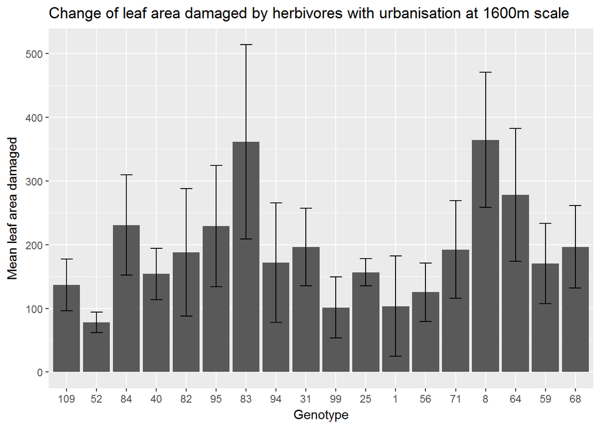

```r
p.area1600 <- ggplot(mRGR.area.BU, aes(x=genotype, y=marea)) +
  geom_bar(stat = "identity",
           position = position_dodge()) +
  geom_errorbar(aes(ymin=marea-sd.area, ymax=marea+sd.area), width=.4,
                position = position_dodge(.9)) +
  labs(title="Change of leaf area damaged by herbivores with urbanisation at 1600m scale", x="Genotype", y="Mean leaf area damaged")
p.area1600
```

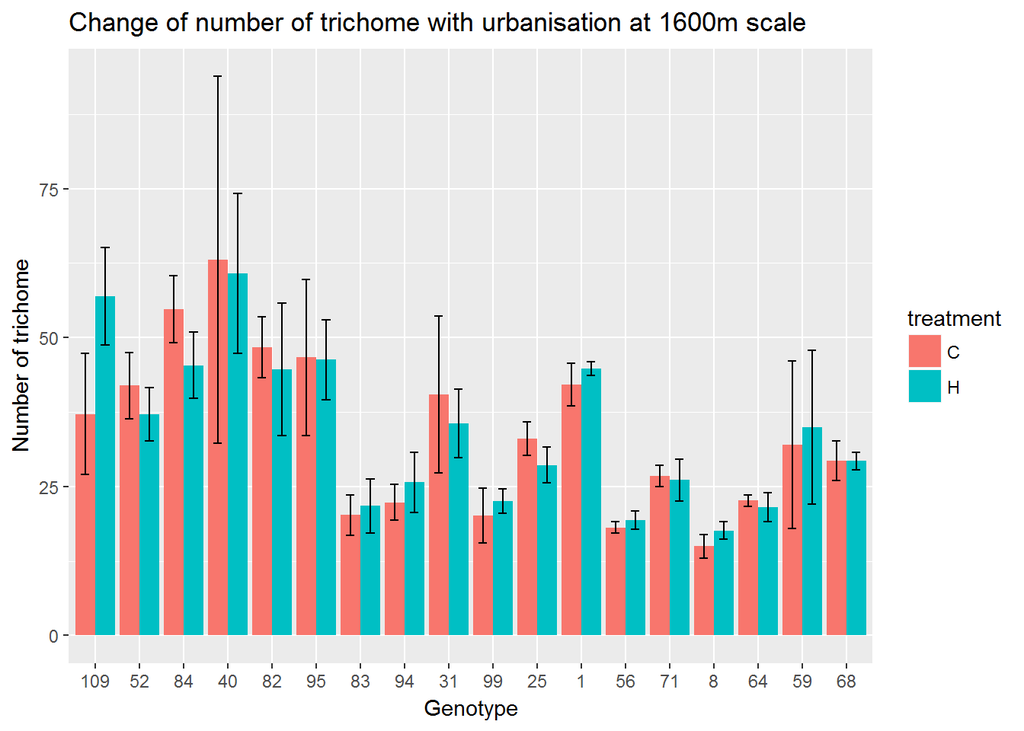

```r
p.tric1600 <- ggplot(mtric.BU, aes(x=genotype, y=mtric, fill=treatment)) +
  geom_bar(stat = "identity",
           position = position_dodge()) +
  geom_errorbar(aes(ymin=mtric-sd.tric, ymax=mtric+sd.tric), width=.4,
                position = position_dodge(.9)) +
  labs(title="Change of number of trichome with urbanisation at 1600m scale", x="Genotype", y="Number of trichome")
p.tric1600
```

# **3.2.7 At 2400m scale**

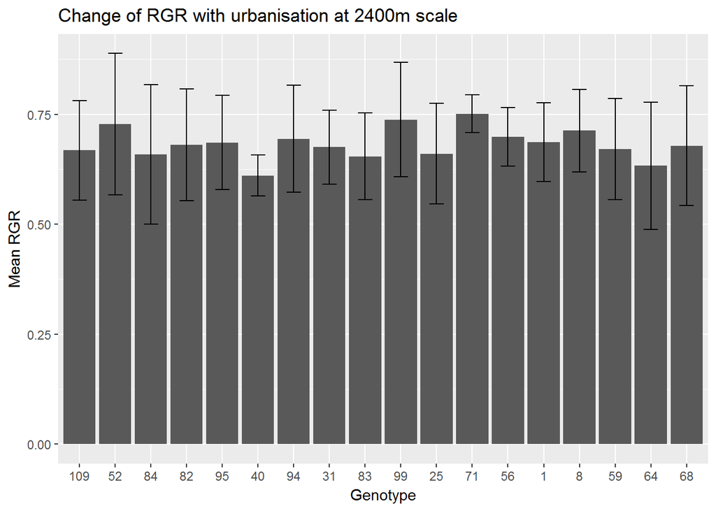

```r
# order genotypes by urbanisation
mRGR.area.BU <- mRGR.area.BU %>% arrange(d2400) %>%
  mutate(genotype = factor(genotype, unique(genotype)))

mtric.BU <- mtric.BU %>% arrange(d2400) %>%
  mutate(genotype = factor(genotype, unique(genotype)))

# make error bar plots
p.RGR2400 <- ggplot(mRGR.area.BU, aes(x=genotype, y=mRGR)) +
  geom_bar(stat = "identity",
           position = position_dodge()) +
  geom_errorbar(aes(ymin=mRGR-sd.RGR, ymax=mRGR+sd.RGR), width=.4,
                position = position_dodge(.9)) +
  labs(title="Change of RGR with urbanisation at 2400m scale", x="Genotype", y="Mean RGR")
p.RGR2400
```

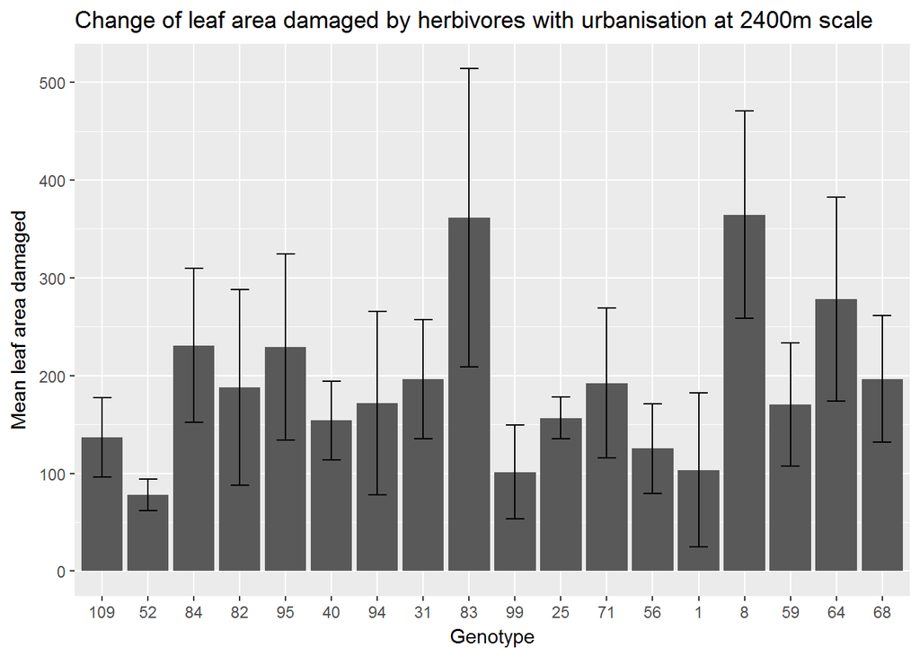

```r
p.area2400 <- ggplot(mRGR.area.BU, aes(x=genotype, y=marea)) +
  geom_bar(stat = "identity",
           position = position_dodge()) +
  geom_errorbar(aes(ymin=marea-sd.area, ymax=marea+sd.area), width=.4,
                position = position_dodge(.9)) +
  labs(title="Change of leaf area damaged by herbivores with urbanisation at 2400m scale", x="Genotype", y="Mean leaf area damaged")
p.area2400
```

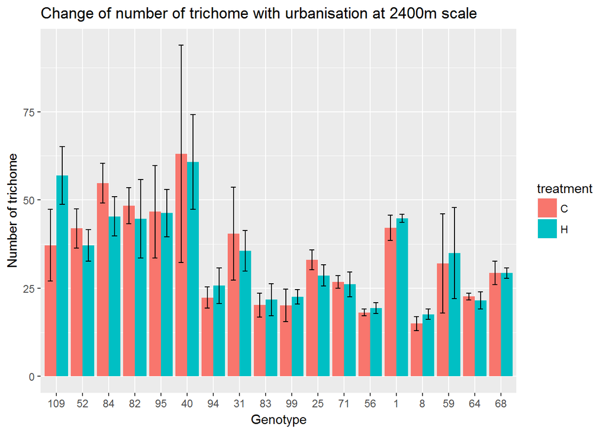

```r
p.tric2400 <- ggplot(mtric.BU, aes(x=genotype, y=mtric, fill=treatment)) +
  geom_bar(stat = "identity",
           position = position_dodge()) +
  geom_errorbar(aes(ymin=mtric-sd.tric, ymax=mtric+sd.tric), width=.4,
                position = position_dodge(.9)) +
  labs(title="Change of number of trichome with urbanisation at 2400m scale", x="Genotype", y="Number of trichome")
p.tric2400
```

# **3.2.8 At 3200m scale**

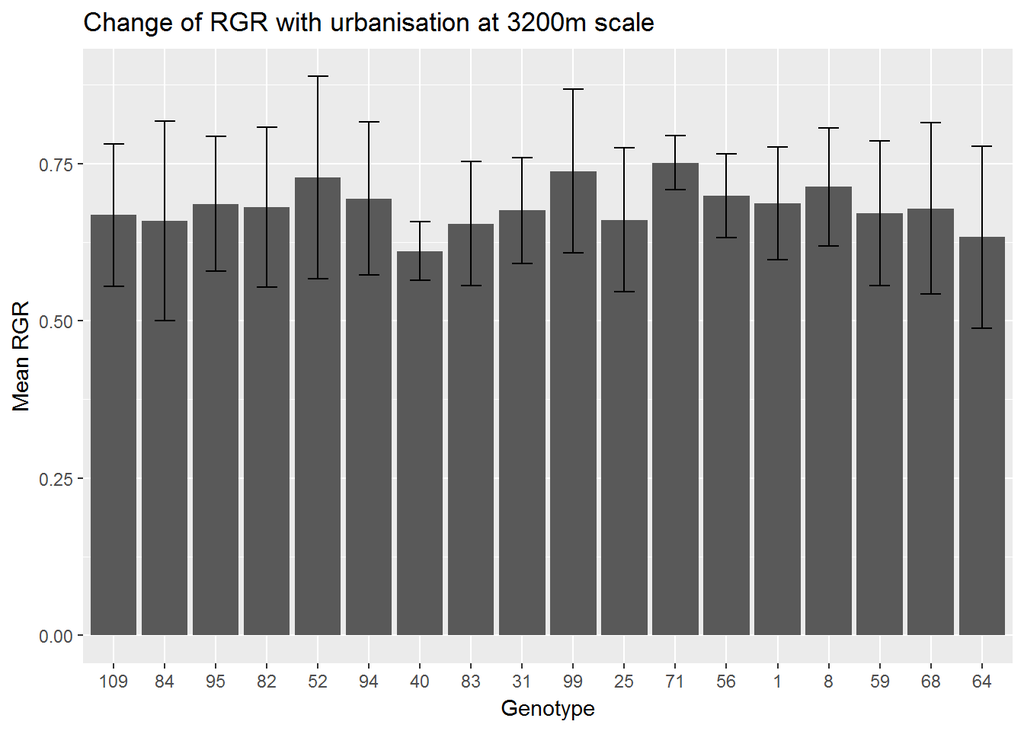

```r
# order genotypes by urbanisation
mRGR.area.BU <- mRGR.area.BU %>% arrange(d3200) %>%
  mutate(genotype = factor(genotype, unique(genotype)))

mtric.BU <- mtric.BU %>% arrange(d3200) %>%
  mutate(genotype = factor(genotype, unique(genotype)))

# make error bar plots
p.RGR3200 <- ggplot(mRGR.area.BU, aes(x=genotype, y=mRGR)) +
  geom_bar(stat = "identity",
           position = position_dodge()) +
  geom_errorbar(aes(ymin=mRGR-sd.RGR, ymax=mRGR+sd.RGR), width=.4,
                position = position_dodge(.9)) +
  labs(title="Change of RGR with urbanisation at 3200m scale", x="Genotype", y="Mean RGR")
p.RGR3200
```

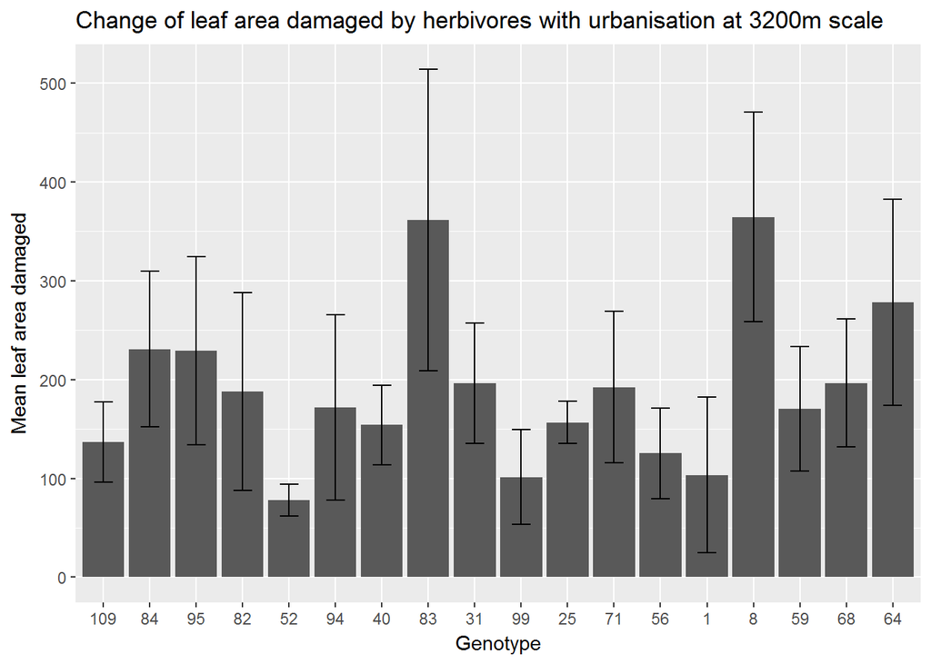

```r
p.area3200 <- ggplot(mRGR.area.BU, aes(x=genotype, y=marea)) +
  geom_bar(stat = "identity",
           position = position_dodge()) +
  geom_errorbar(aes(ymin=marea-sd.area, ymax=marea+sd.area), width=.4,
                position = position_dodge(.9)) +
  labs(title="Change of leaf area damaged by herbivores with urbanisation at 3200m scale", x="Genotype", y="Mean leaf area damaged")
p.area3200
```

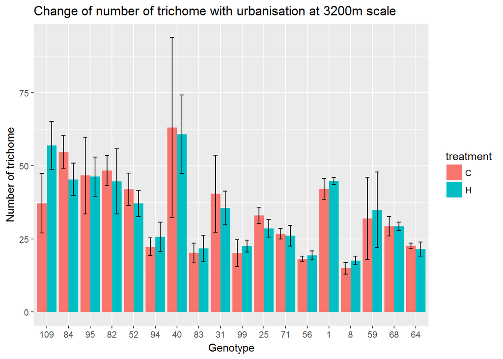

```r
p.tric3200 <- ggplot(mtric.BU, aes(x=genotype, y=mtric, fill=treatment)) +
  geom_bar(stat = "identity",
           position = position_dodge()) +
  geom_errorbar(aes(ymin=mtric-sd.tric, ymax=mtric+sd.tric), width=.4,
                position = position_dodge(.9)) +
  labs(title="Change of number of trichome with urbanisation at 3200m scale", x="Genotype", y="Number of trichome")
p.tric3200
```

Results: Visually, (1) RGR does not differ among genotypes.

2. Leaf area damaged by herbivore differs among genotypes and if they show bell curves for urban and rural genotypes, respectively.
3. Number of trichome differs among genotypes but not between herbivory treatment. Genotypes from rural area have more trichome than that from urban area.

# **3.2.9 Compute one-way ANOVA test**

```r
# dataframes: "herbivory", "trichome"
# Compute the analysis of variance
area.aov <- aov(area.damaged ~ genotype, data = herbivory)
summary(area.aov)
```

```
##             Df Sum Sq Mean Sq F value   Pr(>F)
## genotype    17 544760   32045   5.159 3.58e-07 ***
## Residuals   72 447250    6212
## ---
## Signif. codes:  0 '***' 0.001 '**' 0.01 '*' 0.05 '.' 0.1 ' ' 1
```

```r
RGR.aov <- aov(RGR ~ genotype, data = herbivory)
summary(RGR.aov)
```

```
##             Df Sum Sq  Mean Sq F value Pr(>F)
## genotype    17 0.1051 0.006182   0.482  0.953
## Residuals   72 0.9231 0.012821
```

```r
trichome$genotype <- as.factor(trichome$genotype)
tric.aov <- aov(trichome ~ genotype+treatment, data = trichome)
summary(tric.aov)
```

```
##              Df Sum Sq Mean Sq F value Pr(>F)
## genotype     17  28630  1684.1  23.383 <2e-16 ***
## treatment     1      3     3.2   0.044  0.834
## Residuals   161  11596    72.0
## ---
## Signif. codes:  0 '***' 0.001 '**' 0.01 '*' 0.05 '.' 0.1 ' ' 1
```

```r
# categorize as rural and urban groups
urban50 <- BU %>% top_n(9, d50)      ###select the most urban genotypes
urban50 <- cbind(habitat = "urban", urban50)      ###add a new column marked as "urban" habitat

rural50 <- BU %>% top_n(-9, d50)     ###select the most rural genotypes
rural50 <- cbind(habitat = "rural", rural50)      ###add a new column marked as "rural" habitat

ru50 <- rbind(urban50, rural50)

tric.BU.50 <- merge(trichome, ru50, by = "genotype")
View(tric.BU.50)
# Difference of trichome number between urban and rural genotypes
tric.aov1 <- aov(trichome ~ habitat, data = tric.BU.50)
summary(tric.aov1)
```

```
##              Df Sum Sq Mean Sq F value   Pr(>F)
## habitat       1   3779    3779   18.45 2.86e-05 ***
## Residuals   178  36451     205
## ---
## Signif. codes:  0 '***' 0.001 '**' 0.01 '*' 0.05 '.' 0.1 ' ' 1
```

Results: (1) Differences are shown for “leaf area damaged by herbivores” and “number of trichome” among different genotypes, but not for “relative growth rate of herbivore”.

2. “Number of trichome” does not differ in herbivory and control treatments.
3. “Number of trichome” differs between urban and rural genotypes, and genotypes from rural area have more trichome than that from urban area.

# **4. Model variables with urbanisation**

Model: variables ~ urbanisation

# **4.1. Absolute leaf area damaged by caterpillars**

Make scatterplots of built-up ratio with absolute leaf damage by caterpillars.

```r
# add spatial data to herbivory data
herbivory.BU <- merge(herbivory, BU, by = "genotype")
View(herbivory.BU)
```

# **4.1.1. Based on all observations**

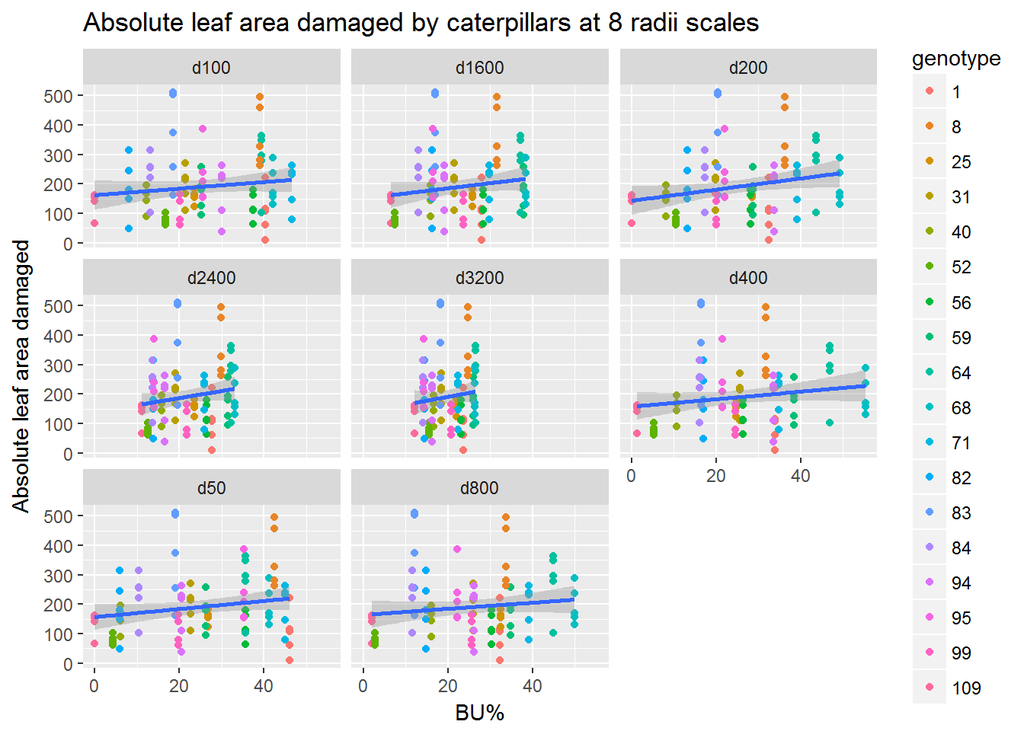

```r
herbivory.BU$genotype <- as.factor(herbivory.BU$genotype)
# gather data by radii
herbivory.BU.L <- gather(herbivory.BU, `d50`, `d100`, `d200`, `d400`, `d800`, `d1600`, `d2400`, `d3200`,
       key = "radii", value = "ratio.bu")
View(herbivory.BU.L)

# create plot
p.dama <- ggplot(herbivory.BU.L) +
  geom_point(mapping = aes(x = ratio.bu, y = area.damaged, colour = genotype)) +
  facet_wrap(~ radii, nrow = 3) +
  labs(title = "Absolute leaf area damaged by caterpillars at 8 radii scales", x = "BU%", y = "Absolute leaf area damaged") +
  geom_smooth(mapping = aes(x = ratio.bu, y = area.damaged), method='lm')
p.dama
```

```r
#make lm models
mod.leaf50 <- lm(herbivory.BU, formula = area.damaged ~ d50)
mod.leaf100 <- lm(herbivory.BU, formula = area.damaged ~ d100)
mod.leaf200 <- lm(herbivory.BU, formula = area.damaged ~ d200)
mod.leaf400 <- lm(herbivory.BU, formula = area.damaged ~ d400)
mod.leaf800 <- lm(herbivory.BU, formula = area.damaged ~ d800)
mod.leaf1600 <- lm(herbivory.BU, formula = area.damaged ~ d1600)
mod.leaf2400 <- lm(herbivory.BU, formula = area.damaged ~ d2400)
mod.leaf3200 <- lm(herbivory.BU, formula = area.damaged ~ d3200)

AIC(mod.leaf50, mod.leaf100, mod.leaf200, mod.leaf400, mod.leaf800, mod.leaf1600, mod.leaf2400, mod.leaf3200)   #d200 has lowest AIC score.
```

```
##              df      AIC
## mod.leaf50    3 1095.797
## mod.leaf100   3 1097.422
## mod.leaf200   3 1094.409
## mod.leaf400   3 1096.704
## mod.leaf800   3 1097.590
## mod.leaf1600  3 1096.812
## mod.leaf2400  3 1096.629
## mod.leaf3200  3 1097.859
```

```r
summary(mod.leaf200)
```

```
##
## Call:
## lm(formula = area.damaged ~ d200, data = herbivory.BU)
##
## Residuals:
##     Min      1Q  Median      3Q     Max
## -196.12  -77.04  -14.71   51.19  329.92
##
## Coefficients:
##             Estimate Std. Error t value Pr(>|t|)
## (Intercept) 143.6032    24.3355   5.901 6.61e-08 ***
## d200          1.8853     0.8688   2.170   0.0327 *
## ---
## Signif. codes:  0 '***' 0.001 '**' 0.01 '*' 0.05 '.' 0.1 ' ' 1
##
## Residual standard error: 103.4 on 88 degrees of freedom
## Multiple R-squared:  0.05079,    Adjusted R-squared:   0.04
## F-statistic: 4.709 on 1 and 88 DF,  p-value: 0.0327
```

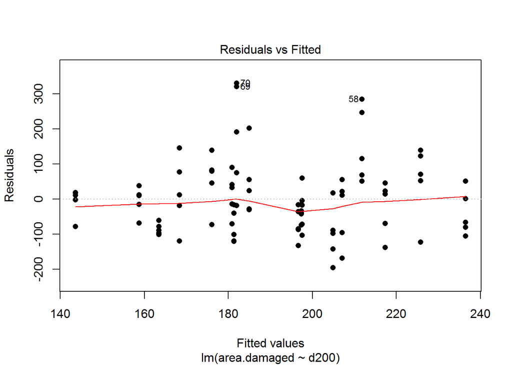

```r
# visualize residuals and fitted values.
plot(mod.leaf200, pch=16, which=1)
```

Results: By making ‘lm’ models at different spatial scales and then comparing the AIC values of all models on ‘absolute leaf area damaged by caterpillars’, the result shows that the model at 200m scale, with positive and significant linear correlation (p=0.0327) of absolute leaf area damaged by caterpillars and urbanisation, is best.

# **4.1.2. Based on average data for each mother plant**

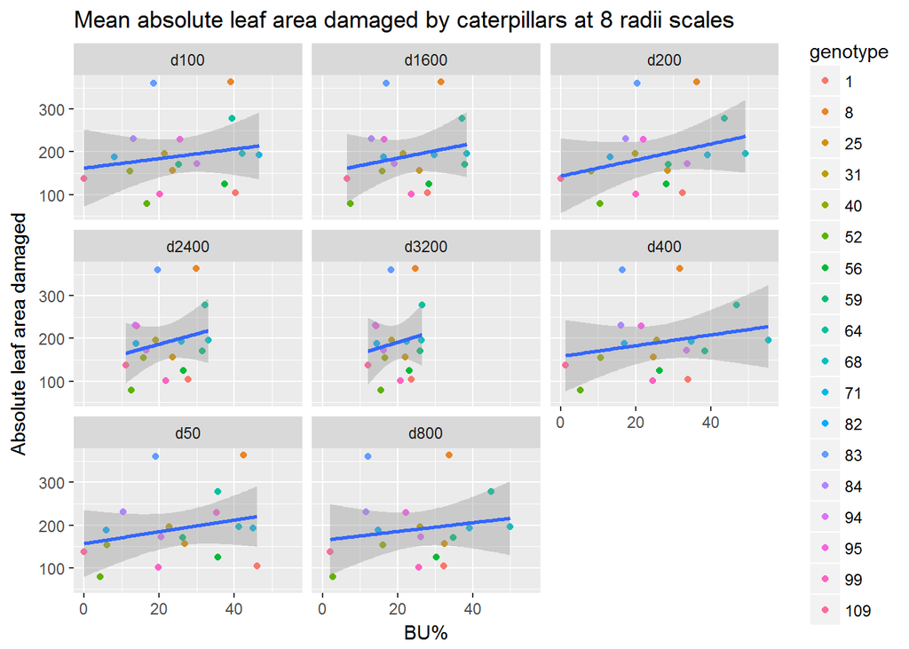

```r
# calculate the mean: summarise()
mean.dama <- ddply(herbivory.BU, "genotype", summarise,
                   mean.dama = mean(area.damaged)
                   )

# combine spatial data and means of absolute leaf area damaged by caterpillars
dama.BU <- merge(mean.dama, BU, by = "genotype")
View(dama.BU)

# gather data
dama.BU.L <- gather(dama.BU, `d50`, `d100`, `d200`, `d400`, `d800`, `d1600`, `d2400`, `d3200`,
       key = "radii", value = "ratio.bu")
View(dama.BU.L)

# create plot
p.mdama <- ggplot(dama.BU.L) +
  geom_point(mapping = aes(x = ratio.bu, y = mean.dama, colour = genotype)) +
  facet_wrap(~ radii, nrow = 3) +
  labs(title = "Mean absolute leaf area damaged by caterpillars at 8 radii scales", x = "BU%", y = "Absolute leaf area damaged") +
  geom_smooth(mapping = aes(x = ratio.bu, y = mean.dama), method='lm')
p.mdama
```

```r
#make lm models
mod.mleaf50 <- lm(dama.BU, formula = mean.dama ~ d50)
mod.mleaf100 <- lm(dama.BU, formula = mean.dama ~ d100)
mod.mleaf200 <- lm(dama.BU, formula = mean.dama ~ d200)
mod.mleaf400 <- lm(dama.BU, formula = mean.dama ~ d400)
mod.mleaf800 <- lm(dama.BU, formula = mean.dama ~ d800)
mod.mleaf1600 <- lm(dama.BU, formula = mean.dama ~ d1600)
mod.mleaf2400 <- lm(dama.BU, formula = mean.dama ~ d2400)
mod.mleaf3200 <- lm(dama.BU, formula = mean.dama ~ d3200)

AIC(mod.mleaf50, mod.mleaf100, mod.mleaf200, mod.mleaf400, mod.mleaf800, mod.mleaf1600, mod.mleaf2400, mod.mleaf3200)   #d200 has lowest AIC score.
```

```
##               df      AIC
## mod.mleaf50    3 212.6093
## mod.mleaf100   3 213.2152
## mod.mleaf200   3 212.0841
## mod.mleaf400   3 212.9486
## mod.mleaf800   3 213.2773
## mod.mleaf1600  3 212.9890
## mod.mleaf2400  3 212.9207
## mod.mleaf3200  3 213.3765
```

```r
summary(mod.mleaf200)
```

```
##
## Call:
## lm(formula = mean.dama ~ d200, data = dama.BU)
##
## Residuals:
##     Min      1Q  Median      3Q     Max
## -101.58  -40.64  -16.01   38.08  179.42
##
## Coefficients:
##             Estimate Std. Error t value Pr(>|t|)
## (Intercept)  143.603     41.353   3.473  0.00314 **
## d200           1.885      1.476   1.277  0.21983
## ---
## Signif. codes:  0 '***' 0.001 '**' 0.01 '*' 0.05 '.' 0.1 ' ' 1
##
## Residual standard error: 78.61 on 16 degrees of freedom
## Multiple R-squared:  0.09249,    Adjusted R-squared:  0.03577
## F-statistic: 1.631 on 1 and 16 DF,  p-value: 0.2198
```

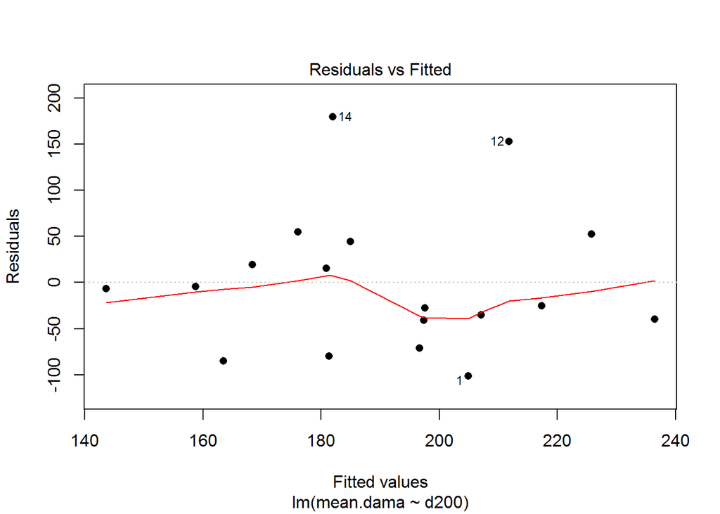

```r
# visualize residuals and fitted values.
plot(mod.mleaf200, pch=16, which=1)
```

Results: By making ‘lm’ models at different spatial scales and then comparing the AIC values of all models on ‘mean absolute leaf area damaged by caterpillars’, the result shows that the model still at 200m scale, with positive but not significant linear correlation (p=0.2198) of mean absolute leaf area damaged by caterpillars and urbanisation, is best, but with very low R2 and large residual standard error.